# **PHdata Northwoord Airline Flight Project Python Code [Justin Dai]**

In this notebook, I am using Python to process, visualize and analyze “Big Data” on airline flights

- **visualization**: matplolib, seaborn
- **data manipulation**: pandas, numpy

This notebook is composed of three parts: cleaning (section 1), exploration (section 2.1-2.6) and final conclusion

**0. Overview**

**1. Cleaning**

- 1.1 Dates and times
- 1.2 Outlier and abnormal value
- 1.3 NA & Missing Value Assessment

**2. Airline & Airport Analytics**

- 2.1 Total number of flights By airline and By airport (on monthly basis)
- 2.2 On time Percentage for each airline at year 2015
- 2.3 Airlines with largest amount of delays
- 2.4 Cancellation reasons by airport
- 2.5. Delay reasons by airport
- 2.6. Airline with the most unique routes

**3.Conclusion**

## 0. Set up & Overview

```python
import pandas as pd
import numpy as np
import seaborn as sns
import matplotlib.pyplot as plt
import warnings
import datetime, warnings, scipy
import matplotlib as mpl
import matplotlib.patches as patches
from matplotlib.patches import ConnectionPatch
from matplotlib.gridspec import GridSpec
plt.rcParams["patch.force_edgecolor"] = True
plt.style.use('fivethirtyeight')
mpl.rc('patch', edgecolor = 'dimgray', linewidth=1)
from IPython.core.interactiveshell import InteractiveShell
InteractiveShell.ast_node_interactivity = "last_expr"
pd.options.display.max_columns = 50
%matplotlib inline
warnings.filterwarnings("ignore")
```

```python
# Connect to snowflake database
import snowflake.connector
import snowflake.connector from snowflake.connector.errors
import DatabaseError,ProgrammingError
# Connecting to Snowflake using the default authenticator
ctx = snowflake.connector.connect(
    user = User,
    password = Password,
    account = Account,
    warehouse = Warehouse,
    database = Database,
    schema = Schema
)
```

```python
#fill in the details and connect to database
account   = "dn61940.ca-central-1.aws"
username  = "justindaisnowflake"
password  = "Snowflake2021"
warehouse = "NWA_DEV_ADMIN_WH"
role      = "NWA_DEV_ANALYST"
database  = "NWA_DEV"
schema    = "AIRLINES_DATA"
cs = ctx.cursor()
df_sp =cs.execute(
"select * from airports").fetchall()
df_sl =cs.execute(
"select * from airlines").fetchall()
df = cs.execute(
"select * from flight/partition-01").fetchall()
```

```python
# Data merge and set up
df_sp = pd.DataFrame(df_sp)
df_sl = pd.DataFrame(df_sl)
df = pd.DataFrame(df)
for i in range(7):
    df_mid = cs.execute("select * from flight/partition-0"+str(i+2)).fetchall()
    df_mid = pd.DataFrame(df_mid)
    df = pd.concat([df,df_mid])
```

```python
#Print out the table information
print('Dataframe dimensions:', df.shape)
#____________________________________________________________
# gives some infos on columns types and number of null values
tab_info=pd.DataFrame(df.dtypes).T.rename(index={0:'column type'})
tab_info=tab_info.append(pd.DataFrame(df.isnull().sum()).T.rename(index={0:'null values (nb)'}))
tab_info=tab_info.append(pd.DataFrame(df.isnull().sum()/df.shape[0]*100)
                         .T.rename(index={0:'null values (%)'}))
tab_info
```

```
Dataframe dimensions: (3920766, 31)
```

|  | YEAR | MONTH | DAY | DAY_OF_WEEK | AIRLINE | FLIGHT_NUMBER | TAIL_NUMBER | ORIGIN_AIRPORT | DESTINATION_AIRPORT | SCHEDULED_DEPARTURE | DEPARTURE_TIME | DEPARTURE_DELAY | TAXI_OUT | WHEELS_OFF | SCHEDULED_TIME | ELAPSED_TIME | AIR_TIME | DISTANCE | WHEELS_ON | TAXI_IN | SCHEDULED_ARRIVAL | ARRIVAL_TIME | ARRIVAL_DELAY | DIVERTED | CANCELLED | CANCELLATION_REASON | AIR_SYSTEM_DELAY | SECURITY_DELAY | AIRLINE_DELAY | … |
| --- | --- | --- | --- | --- | --- | --- | --- | --- | --- | --- | --- | --- | --- | --- | --- | --- | --- | --- | --- | --- | --- | --- | --- | --- | --- | --- | --- | --- | --- | --- |
| column type | int64 | int64 | int64 | int64 | object | int64 | object | object | object | int64 | float64 | float64 | float64 | float64 | float64 | float64 | float64 | int64 | float64 | float64 | int64 | float64 | float64 | int64 | int64 | object | float64 | float64 | float64 | … |
| null values (nb) | 0 | 0 | 0 | 0 | 0 | 0 | 12356 | 0 | 0 | 0 | 69868 | 69868 | 72077 | 72077 | 6 | 83873 | 83873 | 0 | 74550 | 74550 | 0 | 74550 | 83873 | 0 | 0 | 3848073 | 3144810 | 3144810 | 3144810 | … |
| null values (%) | 0 | 0 | 0 | 0 | 0 | 0 | 0.315143 | 0 | 0 | 0 | 1.782 | 1.782 | 1.83834 | 1.83834 | 0.000153031 | 2.1392 | 2.1392 | 0 | 1.90141 | 1.90141 | 0 | 1.90141 | 2.1392 | 0 | 0 | 98.1459 | 80.2091 | 80.2091 | 80.2091 | … |

Each entry of the `flights.csv` file corresponds to a flight record and we see that close to 4 million flights records in there. These flights records all have 31 feature variables. Here are some key variables and their interpratation:

- **YEAR, MONTH, DAY, DAY_OF_WEEK**: dates of the flight
- **AIRLINE**: An identification number assigned by US DOT to identify a unique airline
- **ORIGIN_AIRPORT** and **DESTINATION_AIRPORT**: code attributed by IATA to identify the airports
- **SCHEDULED_DEPARTURE** and **SCHEDULED_ARRIVAL** : scheduled times of take-off and landing
- **DEPARTURE_TIME** and **ARRIVAL_TIME**: real times at which take-off and landing took place
- **DEPARTURE_DELAY** and **ARRIVAL_DELAY**: difference (in minutes) between planned and real times
- **DISTANCE**: distance (in miles)

## 1. Cleaning and Imputation

### 1.1 Dates and times

In `flights.csv`, dates are coded according to 4 variables: **YEAR, MONTH, DAY**, and **DAY_OF_WEEK**. In fact, python offers the *datetime* format which is really convenient to work with dates and times and I thus convert the dates in this format:

```python
df['DATE'] = pd.to_datetime(df[['YEAR','MONTH', 'DAY']])
```

Moreover, in the **SCHEDULED_DEPARTURE** variable, the hour of the take-off is coded as a float where the two first digits indicate the hour and the two last, the minutes. This format is not convenient and I thus convert it. Finally, I merge the take-off hour with the flight date. To proceed with these transformations, I define a few functions:

```python
#_________________________________________________________
# Function that convert the 'HHMM' string to datetime.time
def format_heure(chaine):
    if pd.isnull(chaine):
        return np.nan
    else:
        if chaine == 2400: chaine = 0
        chaine = "{0:04d}".format(int(chaine))
        heure = datetime.time(int(chaine[0:2]), int(chaine[2:4]))
        return heure
#_____________________________________________________________________
# Function that combines a date and time to produce a datetime.datetime
def combine_date_heure(x):
    if pd.isnull(x[0]) or pd.isnull(x[1]):
        return np.nan
    else:
        return datetime.datetime.combine(x[0],x[1])
#_______________________________________________________________________________
# Function that combine two columns of the dataframe to create a datetime format
def create_flight_time(df, col):
    liste = []
    for index, cols in df[['DATE', col]].iterrows():
        if pd.isnull(cols[1]):
            liste.append(np.nan)
        elif float(cols[1]) == 2400:
            cols[0] += datetime.timedelta(days=1)
            cols[1] = datetime.time(0,0)
            liste.append(combine_date_heure(cols))
        else:
            cols[1] = format_heure(cols[1])
            liste.append(combine_date_heure(cols))
    return pd.Series(liste)
```

and I call them to modify the dataframe variables:

```python
df['SCHEDULED_DEPARTURE'] = create_flight_time(df, 'SCHEDULED_DEPARTURE')
df['DEPARTURE_TIME'] = df['DEPARTURE_TIME'].apply(format_heure)
df['SCHEDULED_ARRIVAL'] = df['SCHEDULED_ARRIVAL'].apply(format_heure)
df['ARRIVAL_TIME'] = df['ARRIVAL_TIME'].apply(format_heure)
#__________________________________________________________________________
#df.loc[:5, ['SCHEDULED_DEPARTURE', 'SCHEDULED_ARRIVAL', 'DEPARTURE_TIME',
#             'ARRIVAL_TIME', 'DEPARTURE_DELAY', 'ARRIVAL_DELAY']]
```

Note that in practice, the content of the **DEPARTURE_TIME** and **ARRIVAL_TIME** variables can be a bit misleading since they don't contain the dates. In comparison, the **DEPARTURE_DELAY** and **ARRIVAL_DELAY** variables tend to be much more useful since they directly provides the delays in minutes. As a result, I will not use the **DEPARTURE_TIME** and **ARRIVAL_TIME** variables.

### 1.2 Outlier and abnormal value

I run into a lot of problems with those outliers and abnormal values when I tried to make plots. As a result, I decided to clean them at this "data cleaning" stage

```python
df["AIRLINE"] = df["AIRLINE"].replace(["DTW","E86"],[np.nan,np.nan])
df["ORIGIN_AIRPORT"] = df["ORIGIN_AIRPORT"].replace(['-5','7'],[np.nan,np.nan])
```

### 1.3 NA & Missing Value Assessment

I run into a lot of problems with those outliers and abnormal values when I tried to make plots. As a result, I decided to clean them at this "data cleaning" stage

At this stage, I examine how complete the dataset is:

```python
variables_to_remove = ['TAXI_OUT', 'TAXI_IN', 'WHEELS_ON', 'WHEELS_OFF', 'YEAR',
                       'AIR_SYSTEM_DELAY','SECURITY_DELAY', 'AIRLINE_DELAY', 'LATE_AIRCRAFT_DELAY',
                       'WEATHER_DELAY', 'DIVERTED', 'FLIGHT_NUMBER', 'TAIL_NUMBER', 'AIR_TIME']
df.drop(variables_to_remove, axis = 1, inplace = True)

df[:5]
```

|  | MONTH | DAY | DAY_OF_WEEK | AIRLINE | ORIGIN_AIRPORT | DESTINATION_AIRPORT | SCHEDULED_DEPARTURE | DEPARTURE_TIME | DEPARTURE_DELAY | SCHEDULED_TIME | ELAPSED_TIME | DISTANCE | SCHEDULED_ARRIVAL | ARRIVAL_TIME | ARRIVAL_DELAY | CANCELLED | CANCELLATION_REASON | DATE |
| --- | --- | --- | --- | --- | --- | --- | --- | --- | --- | --- | --- | --- | --- | --- | --- | --- | --- | --- |
| 0 | 1 | 1 | 4 | MQ | TXK | DFW | 2015-01-01 11:25:00 | NaN | NaN | 60.0 | NaN | 181 | 12:25:00 | NaN | NaN | 1 | B | 2015-01-01 |
| 1 | 1 | 1 | 4 | B6 | TPA | LGA | 2015-01-01 11:27:00 | 11:23:00 | -4.0 | 153.0 | 172.0 | 1010 | 14:00:00 | 14:15:00 | 15.0 | 0 | NaN | 2015-01-01 |
| 2 | 1 | 1 | 4 | UA | DEN | IAH | 2015-01-01 11:27:00 | 11:59:00 | 32.0 | 140.0 | 148.0 | 862 | 14:47:00 | 15:27:00 | 40.0 | 0 | NaN | 2015-01-01 |
| 3 | 1 | 1 | 4 | UA | DEN | SFO | 2015-01-01 11:27:00 | 12:13:00 | 46.0 | 167.0 | 132.0 | 967 | 13:14:00 | 13:25:00 | 11.0 | 0 | NaN | 2015-01-01 |
| 4 | 1 | 1 | 4 | EV | RDU | IAH | 2015-01-01 11:25:00 | 11:16:00 | -9.0 | 190.0 | 219.0 | 1042 | 13:35:00 | 13:55:00 | 20.0 | 0 | NaN | 2015-01-01 |

```python
missing_df = df.isnull().sum(axis=0).reset_index()
missing_df.columns = ['variable', 'missing values']
missing_df['filling factor (%)']=(df.shape[0]-missing_df['missing values'])/df.shape[0]*100
missing_df.sort_values('filling factor (%)').reset_index(drop = True)
```

|  | variable | missing values | filling factor (%) |
| --- | --- | --- | --- |
| 0 | CANCELLATION_REASON | 3848073 | 1.854051 |
| 1 | ARRIVAL_DELAY | 83873 | 97.860801 |
| 2 | ELAPSED_TIME | 83873 | 97.860801 |
| 3 | ARRIVAL_TIME | 74550 | 98.098586 |
| 4 | DEPARTURE_DELAY | 69868 | 98.218001 |
| 5 | DEPARTURE_TIME | 69868 | 98.218001 |
| 6 | SCHEDULED_TIME | 6 | 99.999847 |
| 7 | CANCELLED | 0 | 100.000000 |
| 8 | SCHEDULED_ARRIVAL | 0 | 100.000000 |
| 9 | DISTANCE | 0 | 100.000000 |
| 10 | MONTH | 0 | 100.000000 |
| 11 | DESTINATION_AIRPORT | 0 | 100.000000 |
| 12 | ORIGIN_AIRPORT | 0 | 100.000000 |
| 13 | AIRLINE | 0 | 100.000000 |
| 14 | DAY_OF_WEEK | 0 | 100.000000 |
| 15 | DAY | 0 | 100.000000 |
| 16 | SCHEDULED_DEPARTURE | 0 | 100.000000 |
| 17 | DATE | 0 | 100.000000 |

```python
df.head()
```

|  | MONTH | DAY | DAY_OF_WEEK | AIRLINE | ORIGIN_AIRPORT | DESTINATION_AIRPORT | SCHEDULED_DEPARTURE | DEPARTURE_TIME | DEPARTURE_DELAY | SCHEDULED_TIME | ELAPSED_TIME | DISTANCE | SCHEDULED_ARRIVAL | ARRIVAL_TIME | ARRIVAL_DELAY | CANCELLED | CANCELLATION_REASON | DATE |
| --- | --- | --- | --- | --- | --- | --- | --- | --- | --- | --- | --- | --- | --- | --- | --- | --- | --- | --- |
| 0 | 1 | 1 | 4 | MQ | TXK | DFW | 2015-01-01 11:25:00 | NaN | NaN | 60.0 | NaN | 181 | 12:25:00 | NaN | NaN | 1 | B | 2015-01-01 |
| 1 | 1 | 1 | 4 | B6 | TPA | LGA | 2015-01-01 11:27:00 | 11:23:00 | -4.0 | 153.0 | 172.0 | 1010 | 14:00:00 | 14:15:00 | 15.0 | 0 | NaN | 2015-01-01 |
| 2 | 1 | 1 | 4 | UA | DEN | IAH | 2015-01-01 11:27:00 | 11:59:00 | 32.0 | 140.0 | 148.0 | 862 | 14:47:00 | 15:27:00 | 40.0 | 0 | NaN | 2015-01-01 |
| 3 | 1 | 1 | 4 | UA | DEN | SFO | 2015-01-01 11:27:00 | 12:13:00 | 46.0 | 167.0 | 132.0 | 967 | 13:14:00 | 13:25:00 | 11.0 | 0 | NaN | 2015-01-01 |
| 4 | 1 | 1 | 4 | EV | RDU | IAH | 2015-01-01 11:25:00 | 11:16:00 | -9.0 | 190.0 | 219.0 | 1042 | 13:35:00 | 13:55:00 | 20.0 | 0 | NaN | 2015-01-01 |

## 2. Study Airlines & Airport Performances

### 2.0 Exploratory data Analysis

First I want to explore some basic stats about airline to get a general understanding of the data. I want to check the mean delays and percent of flights per company

```python
#__________________________________________________________________
# function that extract statistical parameters from a grouby objet:
def get_stats(group):
    return {'min': group.min(), 'max': group.max(),
            'count': group.count(), 'mean': group.mean()}
#_______________________________________________________________
# Creation of a dataframe with statitical infos on each airline:
global_stats = df['DEPARTURE_DELAY'].groupby(df['AIRLINE']).apply(get_stats).unstack()
global_stats = global_stats.sort_values('count')
```

```
findfont: Font family ['normal'] not found. Falling back to DejaVu Sans.
findfont: Font family ['normal'] not found. Falling back to DejaVu Sans.
findfont: Font family ['normal'] not found. Falling back to DejaVu Sans.
findfont: Font family ['normal'] not found. Falling back to DejaVu Sans.
```

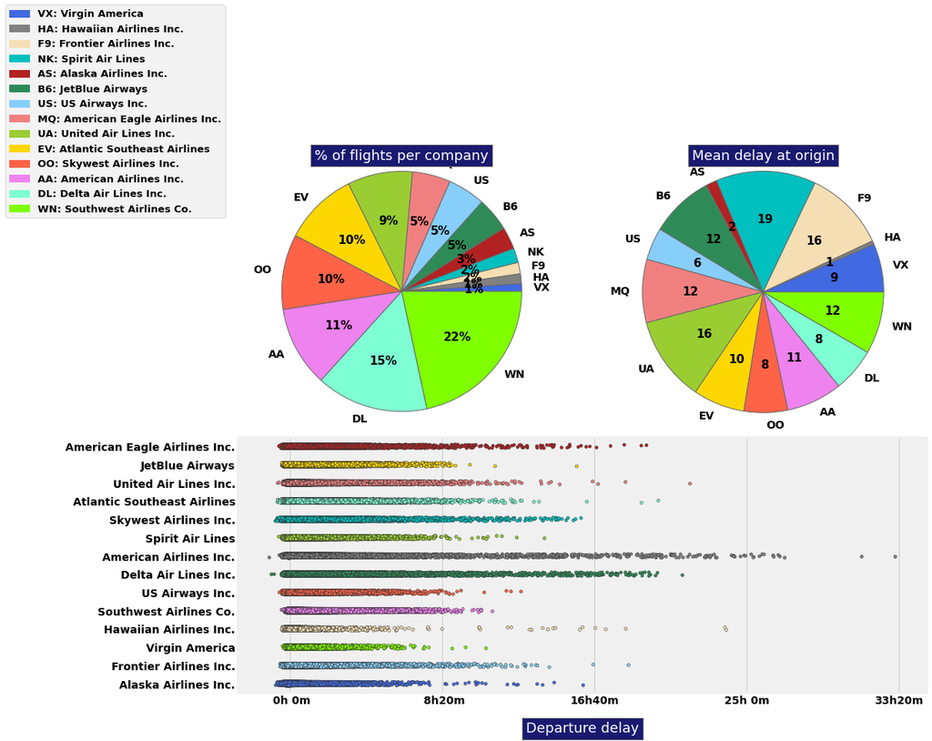

```python
font = {'family' : 'normal', 'weight' : 'bold', 'size'   : 15}
mpl.rc('font', **font)
import matplotlib.patches as mpatches
#__________________________________________________________________
# I extract a subset of columns and redefine the airlines labeling
df2 = df.loc[:, ['AIRLINE', 'DEPARTURE_DELAY']]
df2['AIRLINE'] = df2['AIRLINE'].replace(abbr_companies)
#________________________________________________________________________
colors = ['royalblue', 'grey', 'wheat', 'c', 'firebrick', 'seagreen', 'lightskyblue',
          'lightcoral', 'yellowgreen', 'gold', 'tomato', 'violet', 'aquamarine', 'chartreuse']
#___________________________________
fig = plt.figure(1, figsize=(16,15))
gs=GridSpec(2,2)
ax1=fig.add_subplot(gs[0,0])
ax2=fig.add_subplot(gs[0,1])
ax3=fig.add_subplot(gs[1,:])
#------------------------------
# Pie chart nº1: nb of flights
#------------------------------
labels = [s for s in  global_stats.index]
sizes  = global_stats['count'].values
explode = [0.3 if sizes[i] < 20000 else 0.0 for i in range(len(abbr_companies))]
patches, texts, autotexts = ax1.pie(sizes, explode = explode,
                                labels=labels, colors = colors,  autopct='%1.0f%%',
                                shadow=False, startangle=0)
for i in range(len(abbr_companies)):
    texts[i].set_fontsize(14)
ax1.axis('equal')
ax1.set_title('% of flights per company', bbox={'facecolor':'midnightblue', 'pad':5},
              color = 'w',fontsize=18)
#_______________________________________________
# I set the legend: abreviation -> airline name
comp_handler = []
for i in range(len(abbr_companies)):
    comp_handler.append(mpatches.Patch(color=colors[i],
            label = global_stats.index[i] + ': ' + abbr_companies[global_stats.index[i]]))
ax1.legend(handles=comp_handler, bbox_to_anchor=(0.2, 0.9),
           fontsize = 13, bbox_transform=plt.gcf().transFigure)
#----------------------------------------
# Pie chart nº2: mean delay at departure
#----------------------------------------
sizes  = global_stats['mean'].values
sizes  = [max(s,0) for s in sizes]
explode = [0.0 if sizes[i] < 20000 else 0.01 for i in range(len(abbr_companies))]
patches, texts, autotexts = ax2.pie(sizes, explode = explode, labels = labels,
                                colors = colors, shadow=False, startangle=0,
                                autopct = lambda p :  '{:.0f}'.format(p * sum(sizes) / 100))
for i in range(len(abbr_companies)):
    texts[i].set_fontsize(14)
ax2.axis('equal')
ax2.set_title('Mean delay at origin', bbox={'facecolor':'midnightblue', 'pad':5},
              color='w', fontsize=18)
#------------------------------------------------------
# striplot with all the values reported for the delays
#___________________________________________________________________
# I redefine the colors for correspondance with the pie charts
colors = ['firebrick', 'gold', 'lightcoral', 'aquamarine', 'c', 'yellowgreen', 'grey',
          'seagreen', 'tomato', 'violet', 'wheat', 'chartreuse', 'lightskyblue', 'royalblue']
#___________________________________________________________________
ax3 = sns.stripplot(y="AIRLINE", x="DEPARTURE_DELAY", size = 4, palette = colors,
                    data=df2, linewidth = 0.5,  jitter=True)
plt.setp(ax3.get_xticklabels(), fontsize=14)
plt.setp(ax3.get_yticklabels(), fontsize=14)
ax3.set_xticklabels(['{:2.0f}h{:2.0f}m'.format(*[int(y) for y in divmod(x,60)])
                         for x in ax3.get_xticks()])
plt.xlabel('Departure delay', fontsize=18, bbox={'facecolor':'midnightblue', 'pad':5},
           color='w', labelpad=20)
ax3.yaxis.label.set_visible(False)
#________________________
plt.tight_layout(w_pad=3)
```

As Requested from the executive team at Northwood Airline: I will analyze the airline performances along with the **AIRLINE** and **AIRPORT** attributes (segmented by influencing factors like weather and seasonality) to assess how their competition is performing in the market.

## 2.1 Flight Volumes by Airline & by Airport

As a first step, I consider flight volumes from all carriers and top airports to get a big picture of the market. More specifically, I want to know the Total number of flights By airline and By airport (on monthly basis)

```
findfont: Font family ['normal'] not found. Falling back to DejaVu Sans.
```

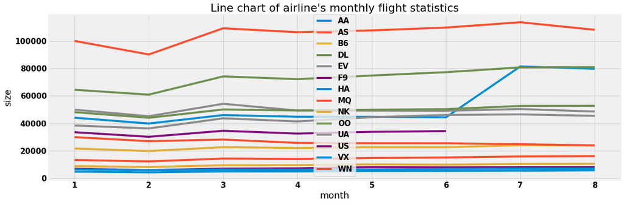

```python
mid_1 = df.groupby(["MONTH","AIRLINE"]).size().reset_index()

plt.figure(figsize=(18,6))
for i in mid_1["AIRLINE"].unique():
    mid_2 = mid_1[mid_1["AIRLINE"]==i]
    plt.plot(mid_2["MONTH"],mid_2[0],label=i)

plt.xlabel("month")
plt.ylabel("size")

plt.title("Line chart of airline's monthly flight statistics")

plt.legend()
plt.show()
```

### Finding (1)

I found that WN and DL has the leading number of flight volumes (throughout the year). Another finding is that the US airline does not have much statistics after the the 6th month of the year

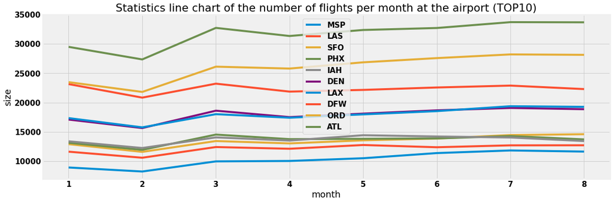

```python
mid_1 = df.groupby(["MONTH","ORIGIN_AIRPORT"]).size().reset_index()

plt.figure(figsize=(18,6))
for i in mid_1.groupby("ORIGIN_AIRPORT").sum().sort_values(0)[-10:].index:
    mid_2 = mid_1[mid_1["ORIGIN_AIRPORT"]==i]
    plt.plot(mid_2["MONTH"],mid_2[0],label=i)

plt.xlabel("month")
plt.ylabel("size")

plt.title("Statistics line chart of the number of flights per month at the airport (TOP10)")

plt.legend()
plt.show()
```

## 2.2 On time Percentage for each airline at year 2015

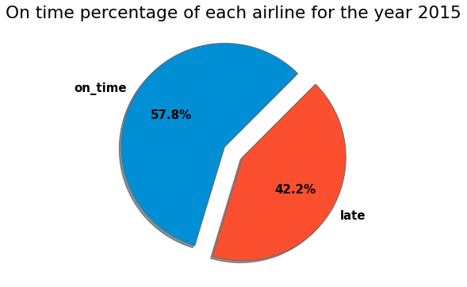

```python
on_time = 0
late = 0
for i in df["ARRIVAL_DELAY"].tolist():
    if i<0:
        on_time = on_time+1
    else:
        late = late + 1

plt.figure(figsize=(6,6))

labels = ["on_time","late"]

explode=(0.1,0.1)

plt.pie([on_time,late],explode=explode,labels=labels,
autopct='%3.1f%%',
startangle=45,
shadow=True)

plt.title("On time percentage of each airline for the year 2015")
plt.show()
```

## 2.3. Airlines with largest amount of delays

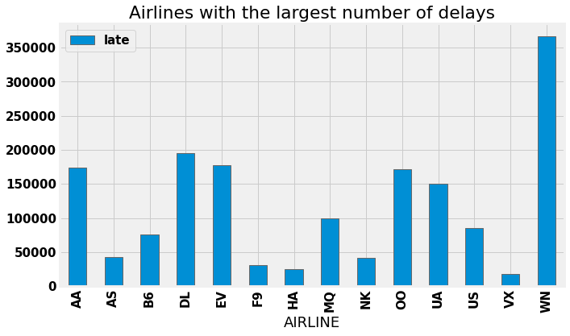

```python
def zs(x):
    if x<0:
        return 0
    else:
        return 1
df["late"] = df["ARRIVAL_DELAY"].apply(zs)

mid_3 = df.groupby(["AIRLINE"]).sum()[["late"]]

mid_3.plot.bar(figsize=(10,6),title=("Airlines with the largest number of delays"))
plt.show()
```

```
findfont: Font family ['normal'] not found. Falling back to DejaVu Sans.
findfont: Font family ['normal'] not found. Falling back to DejaVu Sans.
findfont: Font family ['normal'] not found. Falling back to DejaVu Sans.
```

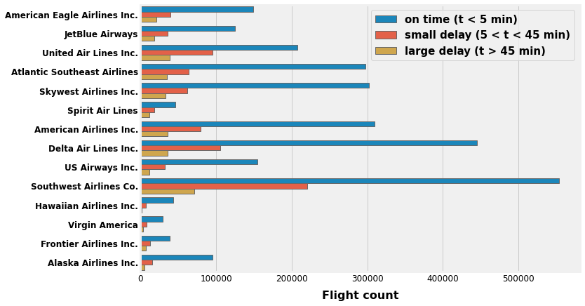

```python
#_____________________________________________
# Function that define how delays are grouped
delay_type = lambda x:((0,1)[x > 5],2)[x > 45]
df['DELAY_LEVEL'] = df['DEPARTURE_DELAY'].apply(delay_type)
#____________________________________________________
fig = plt.figure(1, figsize=(10,7))
ax = sns.countplot(y="AIRLINE", hue='DELAY_LEVEL', data=df)
#____________________________________________________________________________________
# We replace the abbreviations by the full names of the companies and set the labels
labels = [abbr_companies[item.get_text()] for item in ax.get_yticklabels()]
ax.set_yticklabels(labels)
plt.setp(ax.get_xticklabels(), fontsize=12, weight = 'normal', rotation = 0);
plt.setp(ax.get_yticklabels(), fontsize=12, weight = 'bold', rotation = 0);
ax.yaxis.label.set_visible(False)
plt.xlabel('Flight count', fontsize=16, weight = 'bold', labelpad=10)
#________________
# Set the legend
L = plt.legend()
L.get_texts()[0].set_text('on time (t < 5 min)')
L.get_texts()[1].set_text('small delay (5 < t < 45 min)')
L.get_texts()[2].set_text('large delay (t > 45 min)')
plt.show()
```

This figure gives a count of the delays of less than 5 minutes, those in the range 5 < t < 45 min and finally, the delays greater than 45 minutes. Here are 3 major insights from this graph

1. Independently of the airline, delays greater than 45 minutes only account for a few percents.
2. The proportion of delays in these three groups depends on the airline
3. WN (Southwest) airline has significant number of delays compared with other airlines

## 2.3.Extension: Delays segmented by departure & arrival

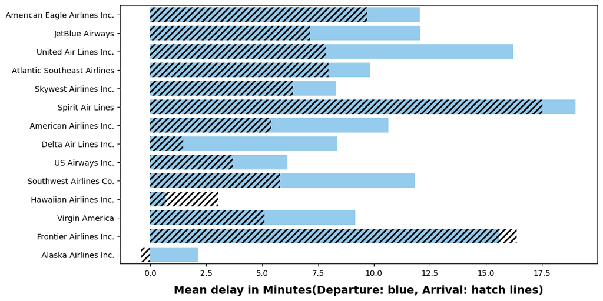

```python
mpl.rcParams.update(mpl.rcParamsDefault)
mpl.rcParams['hatch.linewidth'] = 2.0

fig = plt.figure(1, figsize=(11,6))
ax = sns.barplot(x="DEPARTURE_DELAY", y="AIRLINE", data=df, color="lightskyblue", ci=None)
ax = sns.barplot(x="ARRIVAL_DELAY", y="AIRLINE", data=df, color="r", hatch = '///',
                 alpha = 0.0, ci=None)
labels = [abbr_companies[item.get_text()] for item in ax.get_yticklabels()]
ax.set_yticklabels(labels)
ax.yaxis.label.set_visible(False)
plt.xlabel('Mean delay in Minutes(Departure: blue, Arrival: hatch lines)',
           fontsize=14, weight = 'bold', labelpad=10);
```

On this figure, we can see that delays at arrival are generally lower than at departure. This indicates that airlines adjust their flight speed in order to reduce the delays at arrival. In what follows, I will just consider the delays at departure but one has to keep in mind that this can differ from arrival delays.

## 2.4. Cancellation reasons by airport

I am also interested in finding out which airport leads to largest amount of cancellation. This help me to choose convinent airports if I got the option

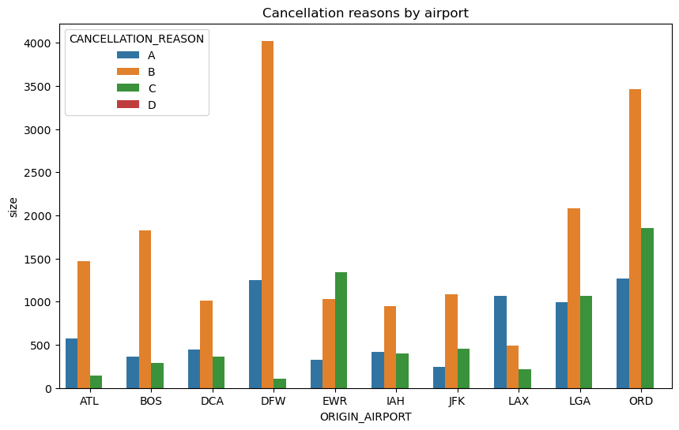

```python
mid_4 = df.groupby(["ORIGIN_AIRPORT","CANCELLATION_REASON"]).size().reset_index(name="size")

mid_4_name = mid_4.groupby("ORIGIN_AIRPORT").sum().sort_values("size")[-10:].index
mid_5 = mid_4[[True if i in mid_4_name else False for i in mid_4["ORIGIN_AIRPORT"]]]

plt.figure(figsize=(10,6))
sns.barplot(x="ORIGIN_AIRPORT", y="size", hue="CANCELLATION_REASON", data=mid_5, ci=None)
plt.title("Cancellation reasons by airport")
plt.show()
```

## 2.5. Delay reasons by airport

I am also interested in finding out what are the reasons for those flight delays. This help me to get an understanding what causes flight delays and potentially avoid it

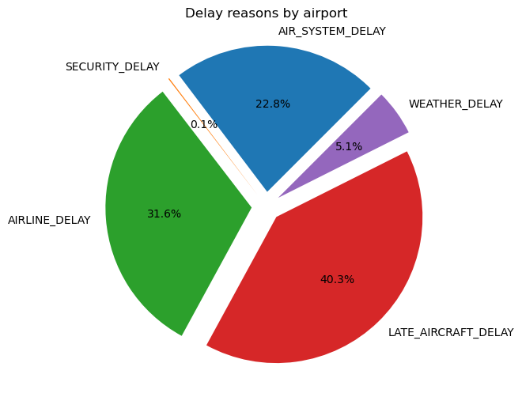

```python
mid_6 = df25[["AIR_SYSTEM_DELAY","SECURITY_DELAY","AIRLINE_DELAY","LATE_AIRCRAFT_DELAY","WEATHER_DELAY"]].sum()

plt.figure(figsize=(6,6))

labels = mid_6.index

explode=(0.1,0.1,0.1,0.1,0.1)

plt.pie(mid_6.tolist(),explode=explode,labels=labels,
autopct='%3.1f%%',
startangle=45,
       )
plt.title("Delay reasons by airport")
plt.show()
```

In general, late_aircraft_delay、air_system_delay、airline_delay are the three major causes of airline delays

```python
mid_7 = pd.merge(df,df_sp,left_on="ORIGIN_AIRPORT",right_on="IATA_CODE")

mid_8 = pd.merge(df,df_sp,left_on="DESTINATION_AIRPORT",right_on="IATA_CODE")

mid_7_s = mid_7[["ORIGIN_AIRPORT","LATITUDE","LONGITUDE"]]
mid_8_s = mid_8[["DESTINATION_AIRPORT","LATITUDE","LONGITUDE"]]
mid_9 = pd.merge(mid_7_s[["LATITUDE","LONGITUDE"]],mid_8_s[["LATITUDE","LONGITUDE"]],on=mid_7_s.index).iloc[:,1:]

mid_9["AIRLINE"] = df["AIRLINE"].dropna().tolist()
mid_9 = mid_9.drop_duplicates()
```

```python
colors = ['#FF9B82', '#00257D', '#007D57', '#647D00', '#7D0064', '#006666','#FF9B00',
          '#1B00FF', '#00E3FF','#64FF00','#FF0064','#0066FF','#173700','#DDC8FA']
colors_dic = {}
for k,i in enumerate(mid_9.index.unique()):
    colors_dic[i]=colors[k]
```

[output not shown]

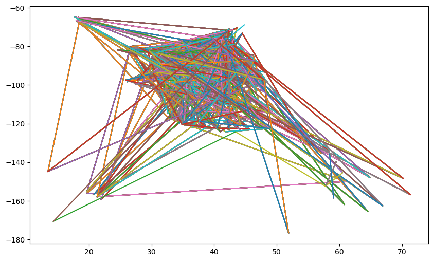

```python
plt.figure(figsize=(10,6))
for i in range(len(mid_9)):
    plt.plot([mid_9.iloc[i,0],mid_9.iloc[i,2]],[mid_9.iloc[i,1],mid_9.iloc[i,3]],
             color=colors_dic.get(mid_9.index[i]))
plt.show()
```

## 3. Conclusion

This notebook was two-fold. The first part dealt with data processing. If have more time, I could do works like imputation and outliers removals to make sure the data is in good quality. The second part would be about the exploration of the dataset, with the aim of understanding some properties of the flight delays&cancellations influenced by time, airports ,airline themselves and other factors. Eventually those are just some simple steps I am taking to explore the data. I spent most of my energy on snowflake & data brick warehousing and BI reporting tasks.